# Data607_Final_project

Charls Joseph

December 5, 2018

### Data Extraction (Tweets Collection - R-Code)

Here, we are going to collect the tweets created for some of newly related products like ‘iphone XS’ and ‘Nexus Pixel’ using tweeter apis(rtweet). rtweet is a wrapper package around the original package ‘tweeteR’

‘search_tweets’ method is being used to pull the tweets. below are description of arguments used.

- **n**= 18000 is max number of tweets that needs to be pulled.
- **include_rts** : whether to include retweet feed or not. For avoiding possible Ads, we chose False for this option.
- **retryonratelimit** : twitter has rate limitation on pull request. So this option will help to wait for next pull the next batch of tweets when the rate is already reached.
- **lang** =‘en’ mentions the langauge. For sake of simplicity, we chose English as the language.
- **q** is the first parameter which is search keyword. We used the hastag #IphoneXS and word ‘iphone XS’ for iphone tweet collections and hashtag #pixel3 and ‘Pixel 3’ for Pixel3 tweet collections.

For sake of scrubbing the consumer and secret keys, I put the entire collecton code into a ‘False’ block. This is just for demonstration in mark down and we executed in our local and made the data available in csv format in github. `

```r
library("rtweet")

if(FALSE) {

create_token(
  app = "my_twitter_research_app",
consumer_key <- '2KljPSOPjhpwbVorrjOWcUL5A',
consumer_secret <- 'jBKaFZcDD1jQGdpqc9eLhGLc4tEvMLSE7jiyybFadmeT0mhZNU',
access_token <- '275643179-fmeAkKNcpaJ6Xq5W7crpeUKwHbGAywRiSUQeARq4',
access_secret <- 'RzKgxz0dErtOnlSNjsQ90zEf1GS281K5M6xsV8s411gXP')

iphone_xs <- search_tweets(
  "#iPhoneXS OR 'iphone XS'", n = 18000, include_rts = FALSE, retryonratelimit = TRUE, lang = 'en'
)

nexus_pxel <- search_tweets(
  "#pixel3 OR pixel3 OR 'Pixel 3'", n = 18000, include_rts = FALSE, retryonratelimit = TRUE, lang = 'en'
)


# write this into a csv file and later uploaded into github for pair programming.
write_as_csv(x = iphone_xs , file_name = 'iphone_xs.csv')
write_as_csv(x = nexus_pxel , file_name = 'tweets_nexus_pxel.csv')


}
```

### Staging the tweet data into mongoDb

One of the best practice in any huge data collection is to persist the row data into a staging table. In Big data world, this is often pushed into a ‘Data Lake’ peristance like Hadoop, NoSql. Then later data analyst and scientists pulls required data they need for analysis and model creation. When the data is collected like this in a real time fashion, the process is called **data pipelining** where data is collected, extracted and cleaned and flow from one phase to another.

Here, we are staging the raw data into a mongodb. We tried to perist into a mysql db, but some of the tweet field is list. so It was not a good idea to save the data into mysql. One way is to save it into a Doumented oriented noSql database like MongoDb. A new column **topic** is added to indicate the topic and the date of collection.

Foe eg: ‘Iphone_2018_12_5’, the topic is ‘Iphone’ and date of collection is ‘2018_12_5’

```r
if(FALSE) {
iphone_xs$topic <- "Iphone_2018_12_5"
nexus_pxel$topic <- "Nexus_Pixel_2018_12_5"


mongodb <- mongo(collection = "tweets_collection", db = "tweeterDatadb")
mongodb$insert(iphone_xs1)
mongodb$insert(nexus_pxel)
}
```

Below is the mongoDB compas view of data.

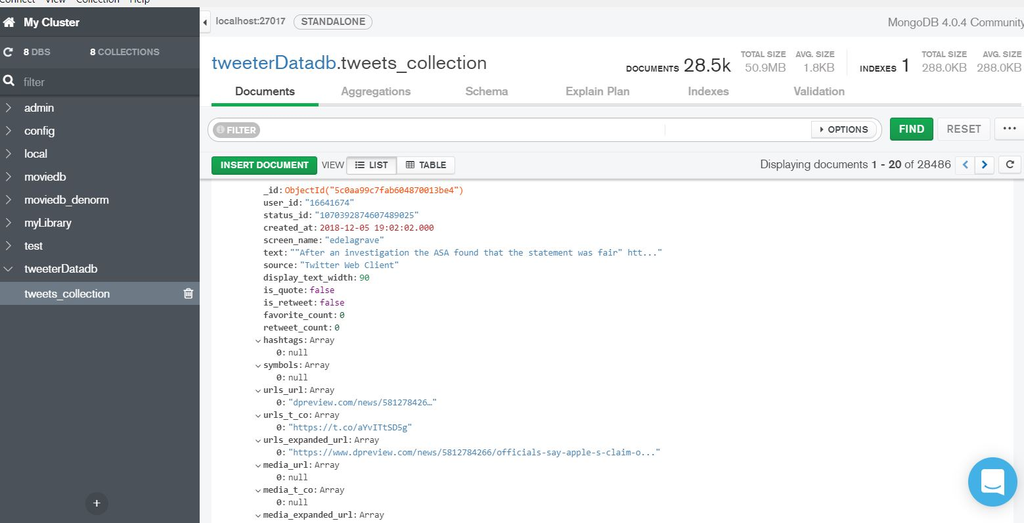

Teets Collection in MongoDB

## Extracting required data from Mongo DB

Below is the code to extract some of relevent data for analysis. we are using mongodb $find method to fetch using **query** and **fields** arguments.

```r
if(FALSE) {

df_iphoneXS<- mongodb$find(query  = '{"topic" : "Iphone_2018_12_5"}',
                   fields  = ' {"user_id": true,
                                "created_at" : true,
                                "screen_name" : true,
                                "text" : true,
                                "source" : true ,
                                "followers_count" : true,
                                "location" : true }' )


df_pixel<- mongodb$find(query  = '{"topic" : "Nexus_Pixel_2018_12_5"}',
                   fields  = ' {"user_id": true,
                                "created_at" : true,
                                "screen_name" : true,
                                "text" : true,
                                "source" : true ,
                                "followers_count" : true,
                                "location" : true }' )

write_as_csv(x = df_iphoneXS , file_name = 'ExtractedData_iphone_xs.csv')
write_as_csv(x = df_pixel , file_name = 'ExtractedData_tweets_nexus_pxel.csv')

}
```

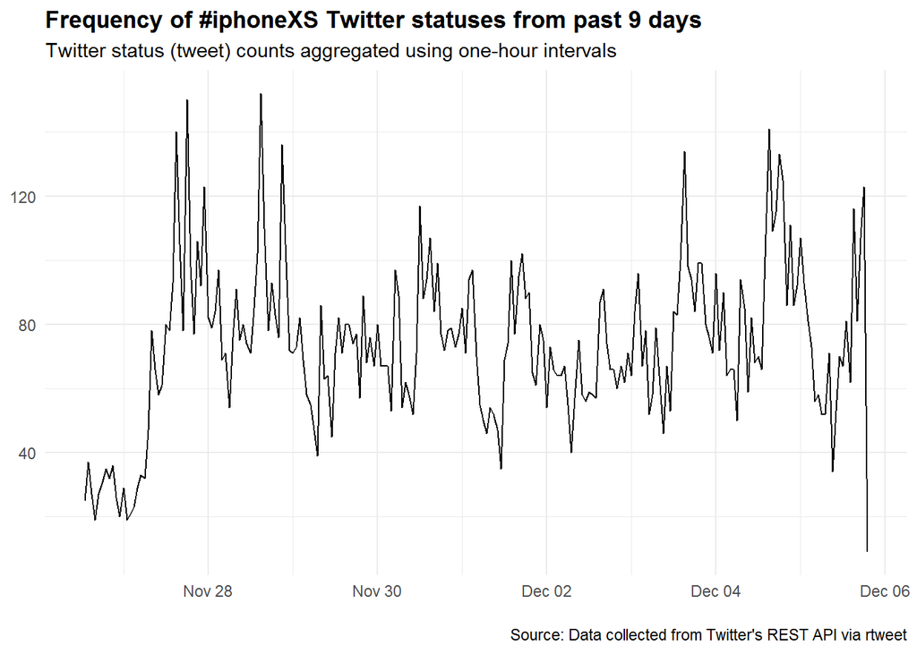

```r
library(readr)
iphone_xs <- read.csv("https://raw.githubusercontent.com/charlsjoseph/CUNY-Data607/master/Data607-Final_Project/iphone_xs.csv")

nexus_pxel <- read.csv("https://raw.githubusercontent.com/charlsjoseph/CUNY-Data607/master/Data607-Final_Project/tweets_nexus_pxel.csv")


ts_plot(iphone_xs, "1 hours") +
  ggplot2::theme_minimal() +
  ggplot2::theme(plot.title = ggplot2::element_text(face = "bold")) +
  ggplot2::labs(
    x = NULL, y = NULL,
    title = "Frequency of #iphoneXS Twitter statuses from past 9 days",
    subtitle = "Twitter status (tweet) counts aggregated using one-hour intervals",
    caption = "\nSource: Data collected from Twitter's REST API via rtweet"
  )
```

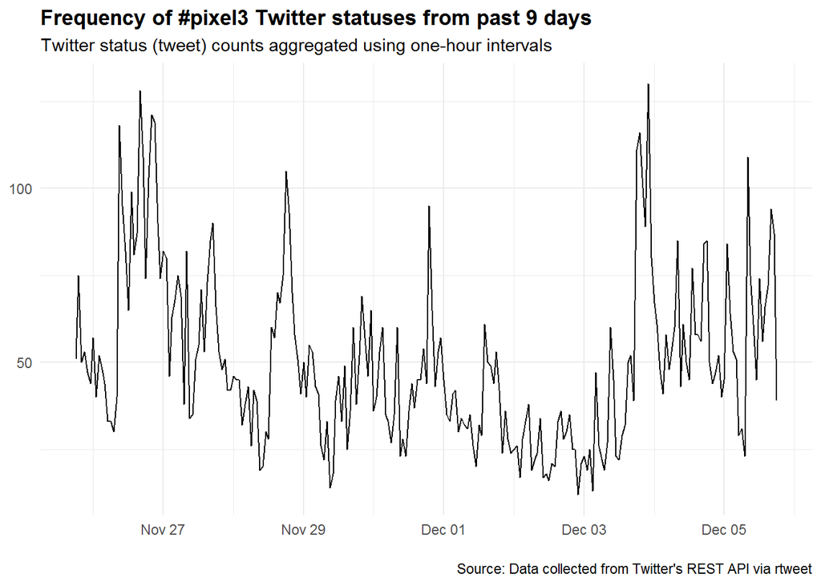

```r
ts_plot(nexus_pxel, "1 hours") +
  ggplot2::theme_minimal() +
  ggplot2::theme(plot.title = ggplot2::element_text(face = "bold")) +
  ggplot2::labs(
    x = NULL, y = NULL,
    title = "Frequency of #pixel3 Twitter statuses from past 9 days",
    subtitle = "Twitter status (tweet) counts aggregated using one-hour intervals",
    caption = "\nSource: Data collected from Twitter's REST API via rtweet"
  )
```

```r
# nrow(df_iphoneXS)
# head(df_iphoneXS)
#
# nrow(df_pixel)
# head(df_pixel)
```

Sentimental polarity check

```r
if(FALSE) {
require(devtools)
#install_github("sentiment140", "okugami79")
library(sentiment)

nrow(iphone_xs)
sentiments_iphone <- sentiment(iphone_xs$text)
table(sentiments_iphone$polarity)

nrow(nexus_pxel)
sentiments_pixel <- sentiment(nexus_pxel$text)
table(sentiments_pixel$polarity)
}
```